# STAT 477 HW3

Charles Yang

2/6/2022

# Problem 1: Sampling Distribution of Proportions

### 1a

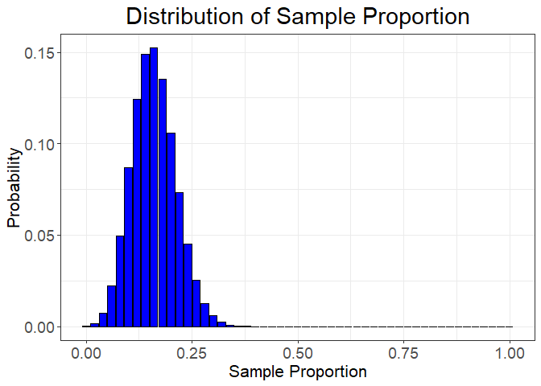

```r
n <- 50
p <- 0.16

pphat <- c(0:n) / n
# Find probability of each possible value from binomial dist.
probpphat <- dbinom(0:n, n, p)
# Form the prior two variables into a dataframe
sdpphat <- as.data.frame(cbind(pphat, probpphat))

# Use ggplot to plot the distribution of phat
ggplot(sdpphat, aes(x = pphat, y = probpphat)) +
    geom_bar(stat = "identity", fill = "blue", colour = "black") +
    theme_bw() +
    theme(
        axis.title.y = element_text(size = rel(1.4)),
        axis.title.x = element_text(size = rel(1.4)),
        axis.text.x = element_text(size = rel(1.6)),
        axis.text.y = element_text(size = rel(1.6)),
        plot.title = element_text(hjust = 0.5, size = rel(2))
    ) +
    labs(
        x = "Sample Proportion",
        y = "Probability",
        title = "Distribution of Sample Proportion"
    )
```

The mean of the sampling distribution is roughly 0.16 as expected. It has noticeable bars spreading out between 0 and 0.375, indicating some variance. The distribution is roughly normal, with the tiniest right skew.

### 1b

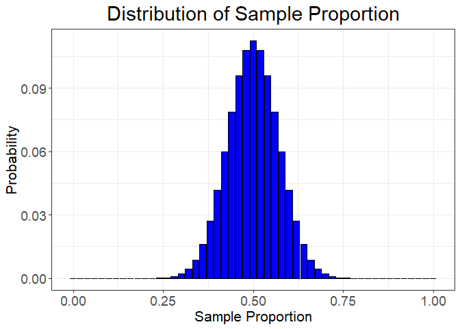

```r
n <- 50
p <- 0.5

pphat <- c(0:n) / n
# Find probability of each possible value from binomial dist.
probpphat <- dbinom(0:n, n, p)
# Form the prior two variables into a dataframe
sdpphat <- as.data.frame(cbind(pphat, probpphat))

# Use ggplot to plot the distribution of phat
ggplot(sdpphat, aes(x = pphat, y = probpphat)) +
    geom_bar(stat = "identity", fill = "blue", colour = "black") +
    theme_bw() +
    theme(
        axis.title.y = element_text(size = rel(1.4)),
        axis.title.x = element_text(size = rel(1.4)),
        axis.text.x = element_text(size = rel(1.6)),
        axis.text.y = element_text(size = rel(1.6)),
        plot.title = element_text(hjust = 0.5, size = rel(2))
    ) +
    labs(
        x = "Sample Proportion",
        y = "Probability",
        title = "Distribution of Sample Proportion"
    )
```

The mean of the sampling distribution is roughly 0.5 as expected. It has noticeable bars spreading out between 0.25 and 0.75, indicating some variance. The distribution is roughly normal and visually symmetric.

### 1c

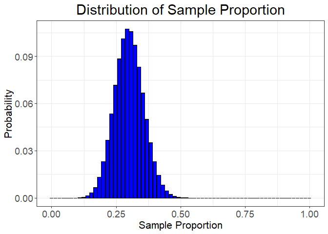

```r
n <- 65
p <- 0.3

pphat <- c(0:n) / n
# Find probability of each possible value from binomial dist.
probpphat <- dbinom(0:n, n, p)
# Form the prior two variables into a dataframe
sdpphat <- as.data.frame(cbind(pphat, probpphat))

# Use ggplot to plot the distribution of phat
ggplot(sdpphat, aes(x = pphat, y = probpphat)) +
    geom_bar(stat = "identity", fill = "blue", colour = "black") +
    theme_bw() +
    theme(
        axis.title.y = element_text(size = rel(1.4)),
        axis.title.x = element_text(size = rel(1.4)),
        axis.text.x = element_text(size = rel(1.6)),
        axis.text.y = element_text(size = rel(1.6)),
        plot.title = element_text(hjust = 0.5, size = rel(2))
    ) +
    labs(
        x = "Sample Proportion",
        y = "Probability",
        title = "Distribution of Sample Proportion"
    )
```

# Problem 2: Disease Treatment

### 2a

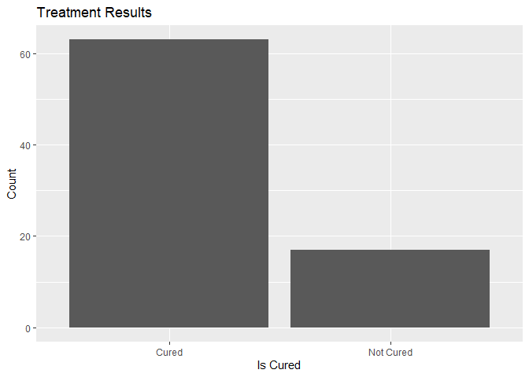

```r
treatment <- read.csv("treatment.csv", header = TRUE)

counts <- treatment %>%
    group_by(Status) %>%
    summarise(count = n())

rel <- counts$count / sum(counts$count)
counts <- cbind(counts, rel)

ggplot(counts, aes(x = Status, y = count)) +
    geom_bar(stat = "identity") +
    labs(
        title = "Treatment Results",
        x = "Is Cured",
        y = "Count"
    )
```

```r
counts
```

```
##      Status count    rel
## 1     Cured    63 0.7875
## 2 Not Cured    17 0.2125
```

### 2b

Well, this example meets the dichotomous and independence assumptions. Although the sample size is relatively small, it still satisfies np and n(1-p) >= 10. So I’m just confused. I’m guessing it’s because the sample size is relatively small.

### 2c

Null Hypothesis: p = 0.62  
Alternative Hypothesis: p > 0.62  
Alpha: 0.05, 95% confidence

```r
binom.test(
    x = counts$count,
    p = 0.62,
    alternative = "greater",
    conf.level = 0.95
)
```

```
##
##  Exact binomial test
##
## data:  counts$count
## number of successes = 63, number of trials = 80, p-value = 0.001035
## alternative hypothesis: true probability of success is greater than 0.62
## 95 percent confidence interval:
##  0.6984758 1.0000000
## sample estimates:
## probability of success
##                 0.7875
```

There is very strong evidence that the new treatment had a higher cure rate than the current treatment.

### 2d

```r
for (i in 50:79) {
    prob <- sum(dbinom(i:80, 80, 0.62))
    if (prob <= 0.05) {
        print(paste0("Successes: ", i, "; Probability: ", prob))
        break
    }
}
```

```
## [1] "Successes: 58; Probability: 0.0323632674897518"
```

Rejection region: 58 <= x <= 80

### 2e

Type 1 error is probability of landing in the rejection region, so it’s 0.0324

### 2f

```r
paste0("Power: ", sum(dbinom(58:80, 80, 0.75)))
```

```
## [1] "Power: 0.744667685036424"
```

### 2g

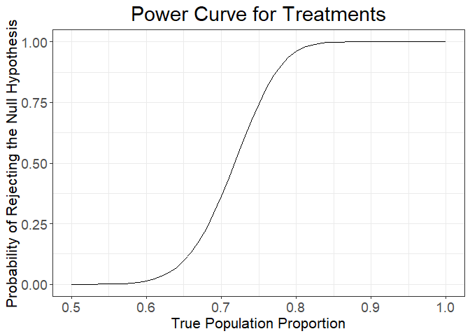

```r
pa <- c(50:100) / 100
# initialize the vector powers with value 99
powers <- rep(99, length(pa))
# calculate the power for each of the values in the vector pa
for (i in 1:length(pa)) powers[i] <- sum(dbinom(58:80, 80, pa[i]))

powerplot <- as.data.frame(cbind(pa, powers))
ggplot(powerplot, aes(x = pa, y = powers)) +
    geom_line() +
    labs(
        x = "True Population Proportion",
        y = "Probability of Rejecting the Null Hypothesis",
        title = "Power Curve for Treatments"
    ) +
    theme_bw() +
    theme(
        axis.title.y = element_text(size = rel(1.4)),
        axis.title.x = element_text(size = rel(1.4)),
        axis.text.x = element_text(size = rel(1.6)),
        axis.text.y = element_text(size = rel(1.6)),
        plot.title = element_text(hjust = 0.5, size = rel(2))
    )
```

As true population proportion increases, Power increases logistically between 0 and 1

# Problem 3: Printer Superbowl Commercial

### 3a

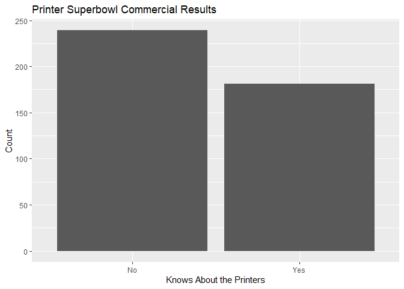

```r
commercial <- read.csv("printer.csv", header = TRUE)

counts <- commercial %>%
    group_by(KnowName) %>%
    summarise(count = n())

rel <- counts$count / sum(counts$count)
counts <- cbind(counts, rel)

ggplot(counts, aes(x = KnowName, y = count)) +
    geom_bar(stat = "identity") +
    labs(
        title = "Printer Superbowl Commercial Results",
        x = "Knows About the Printers",
        y = "Count"
    )
```

```r
counts
```

```
##   KnowName count       rel
## 1       No   239 0.5690476
## 2      Yes   181 0.4309524
```

### 3b

The results are dichotomous and the sample size is sufficiently large to make a binomial exact test hard to do by hand. The score test may be more appropriate than binomial exact here because we can’t exactly assume independence of trials. Groups of people within the sample could know eachother and talked about the printers.

### 3c

```r
prop.test(181, 420, p = 0.4, alternative = "greater", correct = F)
```

```
##
##  1-sample proportions test without continuity correction
##
## data:  181 out of 420, null probability 0.4
## X-squared = 1.6766, df = 1, p-value = 0.09769
## alternative hypothesis: true p is greater than 0.4
## 95 percent confidence interval:
##  0.3917734 1.0000000
## sample estimates:
##         p
## 0.4309524
```

There is little to no evidence that printer recognition is greater than 40%

### 3d

```r
powerprop.test(420, 0.4, 0.45, alternative = "less", 0.01)
```

```
## [1] 6.790022e-06
```

```r
powerprop.test(420, 0.4, 0.45, alternative = "less", 0.05)
```

```
## [1] 0.0001168667
```

```r
powerprop.test(420, 0.4, 0.45, alternative = "less", 0.1)
```

```
## [1] 0.0004473552
```

```r
powerprop.test(420, 0.4, 0.50, alternative = "less", 0.01)
```

```
## [1] 8.963376e-11
```

```r
powerprop.test(420, 0.4, 0.50, alternative = "less", 0.05)
```

```
## [1] 5.63551e-09
```

```r
powerprop.test(420, 0.4, 0.50, alternative = "less", 0.1)
```

```
## [1] 4.291107e-08
```

```r
powerprop.test(420, 0.4, 0.55, alternative = "less", 0.01)
```

```
## [1] 1.227251e-17
```

```r
powerprop.test(420, 0.4, 0.55, alternative = "less", 0.05)
```

```
## [1] 3.12286e-15
```

```r
powerprop.test(420, 0.4, 0.55, alternative = "less", 0.1)
```

```
## [1] 4.991437e-14
```

# Problem 4: Printer Survey Sample size

```r
paste0("n = ", npowerprop.test(0.4, 0.44, alternative = "greater", 0.05, 0.8))
```

```
## [1] "n = 936"
```